# QTM 151 - Quiz 5

## Try to submit as an HTML file

Print your name below

```python
# Write your answer here
print("Garry Zhu")
```

```
Garry Zhu
```

This quiz is open book

- You can use the lecture notes
- You will get partial credit for attempting the questions
- To get full credit, the code should run as intended
- You should NOT communicate with other students

Print the following message:

"I will abide by Emory's code of conduct"

```python
# Write your answer here:

print("I will abide by Emory's code of conduct")
```

```
I will abide by Emory's code of conduct
```

Import the libraries "matplotlib.pyplot" and "pandas"

```python
# Write your answer here
import pandas as pd
import matplotlib.pyplot as plt
```

In this quiz you will work with exchange rate data on bitcoin,  
for two exchange platforms:

- 1 coin base bit coin (CB) to dollar (USD)
- 1 ethereum bit coin (ET) to dollar (USD).

(a) Import and parse dates

- Import the dataset "bitcoin.csv"
- Parse the "date_string" column with `pd.to_datetime()`
- To get full points, set the "format" option using wildcards as in Lecture 21.

```python
dataset = pd.read_csv('data_raw/bitcoin.csv')
dataset["date"] = pd.to_datetime(dataset["date_string"])
```

(b) Plot multiple time series

- Create a line plot plot which has the "cb_to_usd" and "et_to_usd" on the y-axis

and the date on the x-axis

- Label the x-axis, the y-axis, and the title
- Add a legend and set the names to "1 CoinBase bitcoin to USD"

and "1 Ethereum bitcoin to USD"

Hint: See Lecture 22 for how to plot multiple columns  
Hint: Remember to include the legend names as a list `[...]`

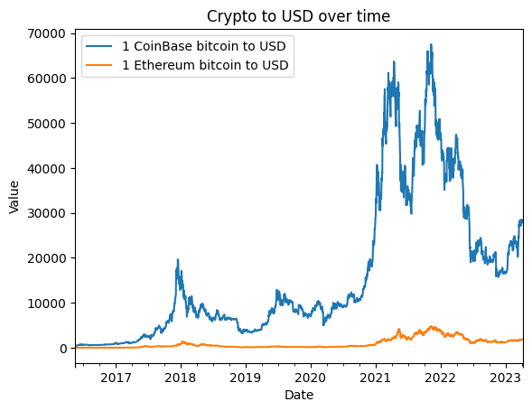

```python
# Write your own code
dataset[["date","cb_to_usd","et_to_usd"]].set_index("date").plot()
plt.xlabel("Date")
plt.ylabel("Value")
plt.title("Crypto to USD over time")
plt.legend(["1 CoinBase bitcoin to USD" ,"1 Ethereum bitcoin to USD"])
```

(c) Compute growth rates

- Calculate a new column "growth_cb" which computes the percentage daily

growth rate of "cb_to_usd".

Hint: Use `.diff()` and `.shift(1)` as in Lecture 22

```python
# Write your own code

dataset["growth_cb1"] = dataset["cb_to_usd"].diff()
dataset["growth_cb2"]    = dataset["cb_to_usd"].shift(1)
dataset["growth_cb"] = dataset["growth_cb1"]* 100/dataset["growth_cb2"]
```

(d) Flag subset of data and plot

- Create a boolean colum (True/False) "bool_cond" which checks whether

"growth_cb" had a value greater than 15 or less than -15

- Generate a line plot with the "growth_cb" series, label the axes and the title
- Use the command `plt.fill_between()` as in Lecture 22 to create a shaded region

for time periods where "bool_cond" is true.

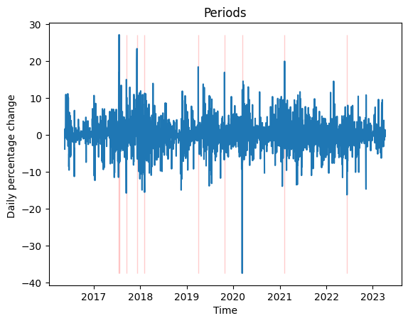

```python
# Write your own code
dataset["bool_cond"] = (dataset["growth_cb"]>15)|(dataset["growth_cb"]<-15)

plt.plot("date", "growth_cb", data = dataset)
plt.xlabel("Time")
plt.ylabel("Daily percentage change ")
plt.title("Periods")

vec_y = dataset["growth_cb"]
plt.fill_between(x= dataset["date"],
                 y1 = vec_y.min(),
                 y2 = vec_y.max(),
                 where = dataset["bool_cond"],
                 alpha = 0.2,color = "red")

plt.show()
```

(e) Aggregate dataset by time period

- Create an object "month_config" that uses `pd.Grouper()`, setting the key to

the date column and freq to "m" (month)

- Follow the instructions in Lecture 21 to compute an aggregate dataset

by month which computes the standard deviation of "cb_to_usd"

- Display the dataset

```python
# Write your own code
month_config = pd.Grouper(key='date', freq='m')

agg_data = (dataset
               .groupby(month_config)
               .agg({'cb_to_usd': 'std'})
               .reset_index())

print(agg_data)
```

```
         date    cb_to_usd
0  2016-05-31    37.522931
1  2016-06-30    67.727627
2  2016-07-31    13.843294
3  2016-08-31    11.616248
4  2016-09-30    10.997678
..        ...          ...
79 2022-12-31   317.869463
80 2023-01-31  2655.277513
81 2023-02-28   947.762915
82 2023-03-31  2826.126499
83 2023-04-30   208.113245

[84 rows x 2 columns]
```

(f) Convert a dataset to long format

- Convert the currencies dataset to long format using the following inputs

```
var_name   = "type",
value_name = "exchange_rate",
id_vars    = "date",
value_vars = ["cb_to_usd","et_to_usd"]
```

- Display the dataset

Hint: See Lecture 22 for details on `pd.melt()`

```python
# Write your own code
dataset_long = pd.melt(dataset,
                         var_name   = "type",
                         value_name = "exchange_rate",
                         id_vars='date',
                         value_vars=['cb_to_usd','et_to_usd'])

display(dataset_long)
```

|  | date | type | exchange_rate |
| --- | --- | --- | --- |
| 0 | 2016-05-18 | cb_to_usd | 455.56 |
| 1 | 2016-05-19 | cb_to_usd | 438.38 |
| 2 | 2016-05-20 | cb_to_usd | 445.65 |
| 3 | 2016-05-21 | cb_to_usd | 446.28 |
| 4 | 2016-05-22 | cb_to_usd | 442.48 |
| ... | ... | ... | ... |
| 5031 | 2023-04-05 | et_to_usd | 1910.39 |
| 5032 | 2023-04-06 | et_to_usd | 1873.51 |
| 5033 | 2023-04-07 | et_to_usd | 1864.71 |
| 5034 | 2023-04-08 | et_to_usd | 1850.01 |
| 5035 | 2023-04-09 | et_to_usd | 1858.23 |

5036 rows × 3 columns